# Assignment #1 - Data Set Selection and Initial Processing

Luka Trkla

## Prerequisite Info on Data Selection

For ease of use, I wanted to include a link to my journal entry page that is complementary to this R Notebook [here](https://github.com/bcb420-2022/Luka_Trkla/wiki/%233---Assignment-1). This R Notebook begins with me already having chosen an expression data set GSE159559 using the techniques shown in Lecture 3 in class. It has the required counts file associated with it in GEO, as we will be interacting with it here. For more detailed information on how this data set was selected, please visit the complementary journal entry.

## Brief Prelude Into the Data Selected.

The experiment pertaining to the data set used in the assignment is of both personal and therapeutic significance. Firstly, I am interested in adenocarcinoma, a form of cancer formed in the glands surrounding organs. Adenocarcinoma often is a likely culprit for metastasizing elsewhere in the body, dramatically increasing patient harm, and decreasing probability of recovery. To add, lung adenocarcinoma metastasizes frequently into the brain, which is a difficult organ for treatment purposes. The experiment posits that FAM83H‐AS1, a noncoding driver of oncogenesis, might potentially be a therapeutic target for lung adenocarcinoma. The experiment provides 3 negative controls for A549 cells in humans, followed by down regulated A549 cells for FAM83H‐AS1, in hopes of illuminating that FAM83H-AS1 inhibits lung adenocarcinoma apoptosis.

## Downloading the Data

Firstly, I want to download any prerequisite packages that I will need to work on the data set, and load it into the library.

```r
# Here I download BiocManager only if it is unavailable prior.
if (!requireNamespace("BiocManager", quietly = TRUE))
  install.packages("BiocManager")
library(BiocManager)

# Here I download GEOmetadb only if it is unavailable prior.
if (!requireNamespace("GEOmetadb", quietly = TRUE))
  BiocManager::install("GEOmetadb")
library(GEOmetadb)
# Here I download edgeR only if it is unavailable prior.
if (!requireNamespace("edgeR", quietly = TRUE))
  BiocManager::install("edgeR")
library(edgeR)
```

Using getGEOSuppFiles from GEOmetadb, I am getting the expression data for GSE159559 (Our data set of interest).

```r
# Getting the expression data for GSE159559.
# Getting the expression data for GSE159559.
supp_files = getGEOSuppFiles('GSE159559')
gse159 <- getGEO("GSE159559",GSEMatrix=FALSE)
```

```
## Reading file....
```

```
## Parsing....
```

```
## Found 7 entities...
```

```
## GPL17303 (1 of 8 entities)
```

```
## GSM4832495 (2 of 8 entities)
```

```
## GSM4832496 (3 of 8 entities)
```

```
## GSM4832497 (4 of 8 entities)
```

```
## GSM4832498 (5 of 8 entities)
```

```
## GSM4832499 (6 of 8 entities)
```

```
## GSM4832500 (7 of 8 entities)
```

## Overview Information for the Data Set

Briefly I want to overview information pertaining to the experiment, to assess if this candidate’s quality is adequate: First, I grab the available information pertaining to GSE159559:

```r
# Grabbing information pertaining to GSE159559
gse159_gpl_info <- Meta(getGEO(names(GPLList(gse159))[1]))
```

Here’s a brief GEO description of the data set

```r
data.frame(head(Meta(gse159)))
```

| contact_address | contact_city | contact_country | contact_department | contact_email | contact_institute |
| --- | --- | --- | --- | --- | --- |
| Baiziting 42 | Nanjing | China | Thoracic Surgery | rong_yin@njmu.edu.cn | Nanjing Medical University Affiliated Jiangsu Cancer Hospital |

**The Platform’s Title:** Ion Torrent Proton (Homo sapiens)

**The Submission Date:** Jun 17 2013

**The Last Update:** Mar 01 2019

Note, there is some unintended behavior here. Both the submission data and last update data from the above queries suggest dates that are older than I was anticipating. On the expression data set GEO website: GSE159559, it states that a “Submission date:”Oct 19, 2020” and a “Last update date Feb 27, 2021”, with the accompanying article to the [dataset](https://www.ncbi.nlm.nih.gov/pmc/articles/PMC7882096/) stating it was published in Feb 14 2021. In any case the data was approved for use in class and falls in the time-span the assignment states, but I can’t figure out why the discrepancy occurred.

**The Organism:**Homo sapiens This satisfies that the data is human.

**Number of GEO Data Sets That use the Same Technology:** 326

**Number of GEO Samples that use this Technology:** 5109

The high numbers of samples and data sets that use the same technology was important for us to observe, as we want to choose an experiment that uses a mature experimental platform, to have high confidence in its quality. This experiment made its expression profile by using high throughput sequencing, specifically using Ion Torrent Proton (Homo sapiens) as its platform.

**Grabbing the expression data from the given data set.**

```r
# Grabbing expression data from data set.
fnames = rownames(supp_files)
fam83_exp = read.delim(fnames[1],header=TRUE, check.names = FALSE)
# Just to see what the unfiltered data set looks like
head(fam83_exp)
```

|  | GeneID | GeneType | NC-1 | NC-2 | NC-3 | Silence-1 | Silence-2 | Silence-3 |
| --- | --- | --- | --- | --- | --- | --- | --- | --- |
| 1 | A1BG | mRNA | 0 | 0 | 0 | 0 | 0 | 0 |
| 2 | A1BG-AS1 | miscRNA | 0 | 1 | 6 | 5 | 1 | 4 |
| 3 | A1CF | mRNA | 0 | 1 | 0 | 0 | 0 | 0 |
| 4 | A2M | mRNA | 0 | 1 | 0 | 2 | 0 | 1 |
| 5 | A2M-AS1 | miscRNA | 7 | 16 | 16 | 7 | 9 | 5 |
| 6 | A2ML1 | mRNA | 0 | 0 | 0 | 0 | 0 | 0 |

Focusing in on just the column names:

```r
colnames(fam83_exp)
```

```
## [1] "GeneID"    "GeneType"  "NC-1"      "NC-2"      "NC-3"      "Silence-1"
## [7] "Silence-2" "Silence-3"
```

Here we can see the data matches the expectations one would have from reading its [GEO page](https://www.ncbi.nlm.nih.gov/geo/query/acc.cgi?acc=GSE159559). We have a GeneID for each row, which is a mapping to unique human gene identifiers, a GeneType, which gives us information on what type of RNA we are using, and 3 replicates of each sample; 3 negative controls for FAM83H‐AS1, and 3 samples where FAM83H‐AS1 was down regulated, or ‘silenced’. The data having at least 3 replicates and being produced relative recently adds to our evidence for the experiment being of high-quality.

Based on reading the information online pertaining to the data set, I suspect that fam83$geneID will already be mapped properly for future use as HUGO gene identifiers. Looking at the the number of genes in the data set compared to the number of unique gene names in the data set will give us some insight into how many duplicate genes are in the data set.

```r
# Looking if all genes are unique in list.
length(fam83_exp$GeneID)
```

```
## [1] 40173
```

```r
# Compared to the number of unique genes in the list.
length(unique(fam83_exp$GeneID))
```

```
## [1] 40173
```

Both give the result #[1] 40173 as of submission date for assignment.

## Data Set Mapping & Cleaning

These both giving an identical result suggests that we do not have the case where a set of rows map on to the same symbol. The lectures show gene duplications with a modified version of the following code.

```r
summarized_gene_counts <- sort(table(fam83_exp$GeneID), decreasing = TRUE)
head(summarized_gene_counts)
```

```
##
##     A1BG A1BG-AS1     A1CF      A2M  A2M-AS1    A2ML1
##        1        1        1        1        1        1
```

Clearly this set doesn’t have duplicates. To add, the number of unique gene names matches the number of gene entries in the data set, which tells us that we don’t have an issue of an unmapped row, or any anomalous identifier we would have to remedy for. Overall, I feel confident saying, based on the overview done prior and following, that the quality of data we’re working with is high.

```r
#the dim of the data set should be 40173
dim(fam83_exp)
```

```
## [1] 40173     8
```

Each row is assigned a unique gene identifier, relative to the other identifiers in the set, all already in the same HUGO format. Below I grab the identifiers used in the data for negative control and silenced data respectively, placing them in a data.frame. I didn’t really have to do this step, as my data is simply 3 negative controls followed by 3 experimental sets where FAM83H-AS1 is silenced, so I could have just grabbed the two identifiers that describe the sets in the data: ‘NC’ and ‘Silence’. I thought though that it would be useful to rewrite the code to further my understanding of how it works.

```r
# Grabbing the identifiers used in the data for negative control and silenced
# data respectively.
sample_info <- data.frame(lapply(colnames(fam83_exp)[3:8],
    FUN=function(x){unlist(strsplit(x, split = "-"))[c(1,2)]}))
colnames(sample_info) <- colnames(fam83_exp)[3:8]
rownames(sample_info) <- c("cell_type", "sample_number")
sample_info <- data.frame(t(sample_info))
```

**Cleaning** Going forward, I want to being filtering out low count entries in the data set. In the R code here, I go into more detail about the method chosen to do this.

```r
# Filtering out low counts. I used the method that was suggested by edgeR; to
# remove features without at least 1 read per million in the 3 of our samples.
# This is because the smallest group of replicates in my experiment is 3.
cpms = cpm(fam83_exp[,3:8])
rownames(cpms) <- fam83_exp[,1]
# Filtering low-occurrence entries to fam83_exp.
fam83_exp = fam83_exp[rowSums(cpms >1) >=3,]
dim(fam83_exp)
```

```
## [1] 15082     8
```

```r
# 15082     8, 15082 is much more manageable (as of submission date for assignment.)
```

By filtering, we have made the number of genes being analyzed much more ‘manageable’, removing 25091 gene entries from our data set. A total of 15082 is much more in line with our class expectations for a well covered data set, but does not filter too much and produce a measurement for only a small amount of genes. Although technically speaking, measurement error will almost certainly occur with any set of measurements, our filtering is not done in a ‘biased’ way to exacerbate some pre-existing measurement error inherent to the data set. Rather, we are uniformly applying a minimal threshold for low occurring entries. These removed data points would likely not contribute meaningfully to the hypothesis being resolved in the experiment, but may contribute to measuring errors if left in the set.

Here I assign the row names to be the HUGO gene symbols for each row.

```r
# The provided Gene IDs from the data set are HUGO gene symbols, each of which is
# unique relative to the rest of the data set. Here I am just making the
# row names correspond to the Gene Id the row pertains to.
rownames(fam83_exp) <- fam83_exp$GeneID

# Here I trim off geneType and geneID, to get the data.frame of the desired
# result specified by the assignment.
fam83_exp <- subset(fam83_exp, select = -c(GeneID, GeneType))
```

## Data Normalization

Following the course lecture on normalization, it became pertinent for me to find a normalization technique that would improve our ability to observe biological variation, while minimizing technical variation. To do so would require a RNA-Seq compatible method for producing relative RNA levels between samples. In reading the articles associated with the lecture, alongside the article associated with the data set, a normalization across the sample would be appropriate under the assumption that the majority of genes are not differentially expressed, which is a characteristic reflected in the data set’s experiment. For these reasons, ‘Trimmed Mean of M-values’ is an appropriate sample based normalization technique for the samples in my data set.

The following code is adapted from the lecture material, and performs a TMM normalization on our filtered data set.

```r
d = DGEList(counts=as.matrix(fam83_exp[,1:6]), group=sample_info$cell_type)
# Calculates normalization factors, using TMM.
d = calcNormFactors(d, method="TMM")
# Grabbing the normalized data.
fam83_norm <- cpm(d)
```

## Pre & Post Normalization plots.

The following code is modified from the lecture notes to produce the 3 sets of plots that are most pertinent to analyzing the distributions of our data. For comparative reasons the density and boxplots are plotted in tandem to produce both plots side by side to each other. Here is the code for graphing the boxplot for the sample compared to the normalized sample.

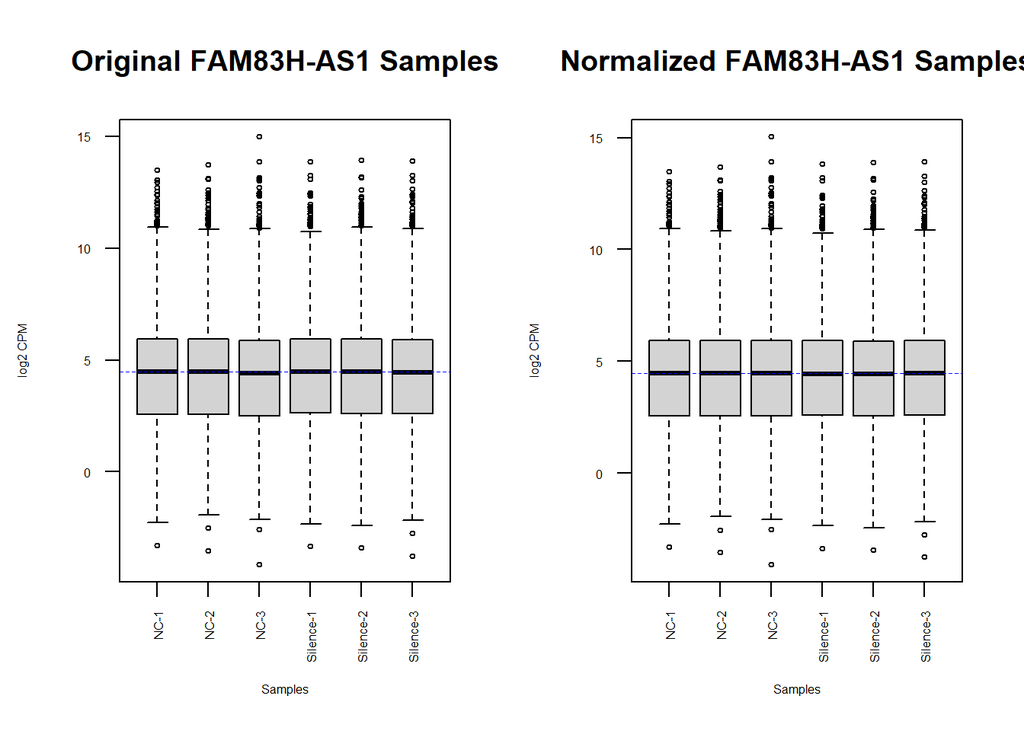

```r
#Let's us graph both
par(mfrow=c(1,2))
#BOX PLOT SAMPLE
sampleplot <- log2(cpm(fam83_exp[]))
boxplot(sampleplot, xlab = "Samples", ylab = "log2 CPM",
        las = 2, cex = 0.5, cex.lab = 0.5,
        cex.axis = 0.5, main = "Original FAM83H-AS1 Samples")
#draw the median on each box plot
abline(h = median(apply(sampleplot, 2, median)),
       col = "blue", lwd = 0.6, lty = "dashed")

#BOX PLOT NORMALIZED
normplot <- log2(fam83_norm[])
boxplot(normplot, xlab = "Samples", ylab = "log2 CPM",
        las = 2, cex = 0.5, cex.lab = 0.5,
        cex.axis = 0.5, main = "Normalized FAM83H-AS1 Samples")
#draw the median on each box plot
abline(h = median(apply(normplot, 2, median)),
       col = "blue", lwd = 0.6, lty = "dashed")
```

It’s easier to observe the intended result of the normalization when you blow up the size of the box plots onto a larger side window as the differences are minute, but in the normalized plot you can observe a slight ‘straightening’ of the box plots between samples, which makes sense for a normalized data set. The distributions are more or less the same, but they are better aligned.

Below is the code for producing the density plots for our samples pre and post normalization, followed by a discussion on any observations. It was modified from the lecture notes on how to produce this plot.

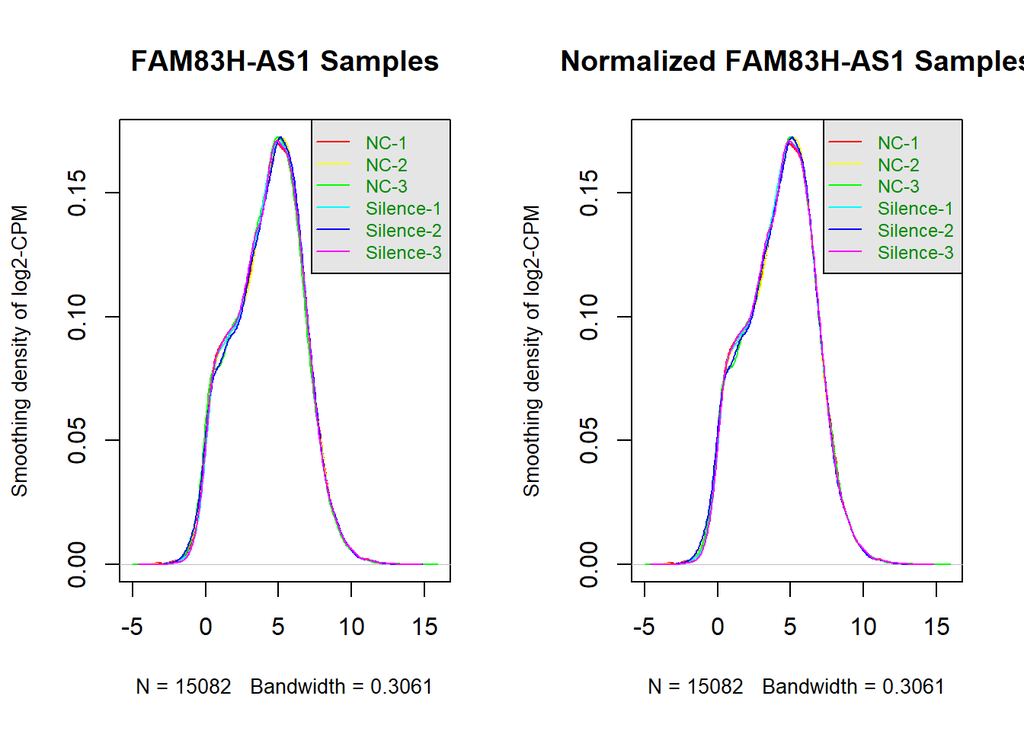

```r
par(mfrow=c(1,2))
sample_density <- apply(log2(cpm(fam83_exp)),
                        2, density)
norm_density <- apply(log2(fam83_norm),
                             2, density)
#calculate the limits across all the samples
xlim <- 0; ylim <- 0
for (i in 1:length(sample_density)) {
  xlim <- range(c(xlim, sample_density[[i]]$x));
  xlim <- range(c(xlim, norm_density[[i]]$x));
  ylim <- range(c(ylim, sample_density[[i]]$y));
  ylim <- range(c(ylim, norm_density[[i]]$y))
}

#calculate the limits across all the samples
cols <- rainbow(length(sample_density))
ltys <- rep(1, length(sample_density))
#plot the first density plot to initialize the plot
plot(sample_density[[1]], xlim=xlim, ylim=ylim, type="n",
     ylab="Smoothing density of log2-CPM",
     main="FAM83H-AS1 Samples", cex.lab = 0.85)
#plot each line
for (i in 1:length(sample_density))
  lines(sample_density[[i]], col=cols[i], lty=ltys[i])
#create legend
legend("topright", colnames(normplot),
       col=cols, lty=ltys, cex=0.75,
       border ="blue", text.col = "green4",
       merge = TRUE, bg = "gray90")

#DENSITY PLOT 2 NORM
#calculate the limits across all the samples
cols <- rainbow(length(norm_density))
ltys <- rep(1, length(norm_density))
#plot the first density plot to initialize the plot
plot(norm_density[[1]], xlim=xlim, ylim=ylim, type="n",
     ylab="Smoothing density of log2-CPM",
     main="Normalized FAM83H-AS1 Samples", cex.lab = 0.85)
#plot each line
for (i in 1:length(norm_density))
  lines(norm_density[[i]], col=cols[i], lty=ltys[i])
#create legend
legend("topright", colnames(normplot),
       col=cols, lty=ltys, cex=0.75,
       border ="blue", text.col = "green4",
       merge = TRUE, bg = "gray90")
```

I notice that the distributions look similar, but there is a marginal improvement with respect to the distribution of outliers. That is to say there is less variation in these outliers, which suggests that we’ve successfully removed some technical variation from the sample.

Multi-dimension scaling plots let us look at distribution in a different way. Here is how to produce one for the data set.

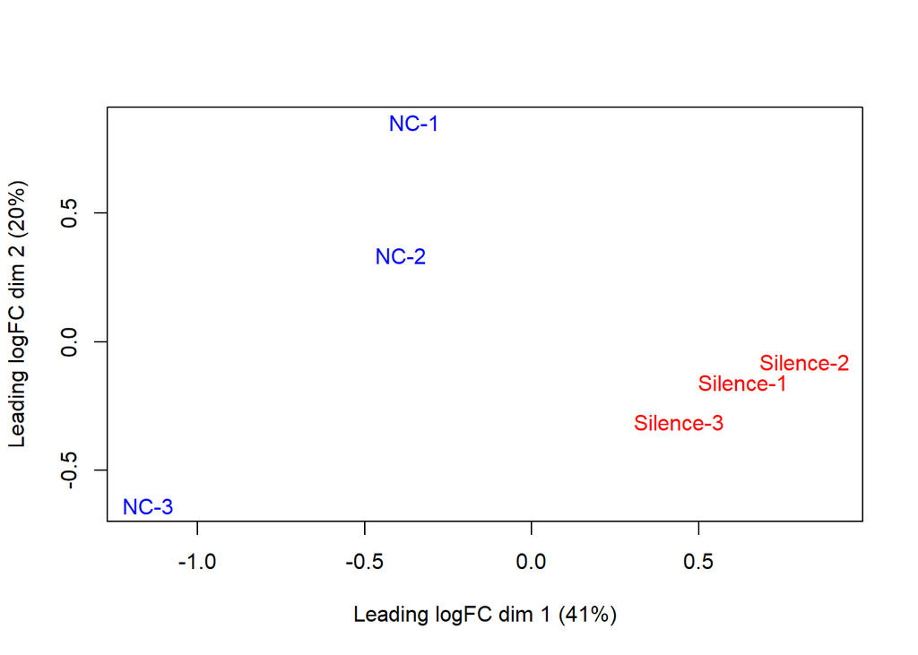

```r
plotMDS(d, labels=rownames(sample_info), col = c("blue", "red")[factor(sample_info$cell_type)])
```

Our Condition, the silencing of the gene, seems to have strong clustering, whereas out control has much greater distribution. This might suggest the condition is powerful, as we are seeing strong separation.

## Resulting Data Frame

fam83_exp is the resulting data frame for the sample that has HUGO symbols as row names, and has x numeric columns where x = 6 (3 controls, 3 experiments). fam83_norm will be an equivalent data frame for the normalized solutions, which I code for below:

```r
fam83_norm <- as.data.frame(fam83_norm)
head(fam83_exp)
```

|  | NC-1 | NC-2 | NC-3 | Silence-1 | Silence-2 | Silence-3 |
| --- | --- | --- | --- | --- | --- | --- |
| A4GALT | 177 | 164 | 258 | 168 | 172 | 198 |
| AAAS | 815 | 1039 | 1524 | 846 | 954 | 1170 |
| AACS | 731 | 788 | 1356 | 788 | 882 | 1088 |
| AADAT | 47 | 86 | 120 | 37 | 56 | 57 |
| AAED1 | 88 | 114 | 179 | 73 | 100 | 112 |
| AAGAB | 450 | 636 | 895 | 526 | 639 | 699 |

## Final Questions

I have addressed all of these questions at greater detail throughout this R Notebook, but for the purposes of helping the reader I have curated the answers here:

**What are the control and test conditions of the dataset?** The experiment provides 3 negative controls for A549 cells in humans, followed by down regulated A549 cells for FAM83H‐AS1, in hopes of illuminating that FAM83H-AS1 inhibits lung adenocarcinoma apoptosis. This selection of control and test condition will give us an opportunity to see how FAM83H-AS1 influences the expression of other genes in the cell.

**Why is the dataset of interest to you?** The experiment pertaining to the data set used in the assignment is of both personal and therapeutic significance. Firstly, I am interested in adenocarcinoma, a form of cancer formed in the glands surrounding organs. Adenocarcinoma often is a likely culprit for metastasizing elsewhere in the body, dramatically increasing patient harm, and decreasing probability of recovery. To add, lung adenocarcinoma metastasizes frequently into the brain, which is a difficult organ for treatment purposes. The experiment posits that FAM83H‐AS1, a noncoding driver of oncogenesis, might potentially be a therapeutic target for lung adenocarcinoma. The experiment provides 3 negative controls for A549 cells in humans, followed by down regulated A549 cells for FAM83H‐AS1, in hopes of illuminating that FAM83H-AS1 inhibits lung adenocarcinoma apoptosis.

**Were there expression values that were not unique for specific genes? How did you handle these?** This did not occur as all the expression values were unique to specific genes.

**Were there expression values that could not be mapped to current HUGO symbols?** All expression values were mapped to current HUGO symbols.

**How many outliers were removed?** 25091 outliers were removed.

**How did you handle replicates** The replicates of the data set were labelled “NC-1”, “NC-2”, “NC-3”, “Silence-1”, “Silence-2”, & “Silence-3”. Reading the [data set webpage](https://www.ncbi.nlm.nih.gov/geo/query/acc.cgi?acc=GSE159559) it is clear that NC-# pertains to the #th Negative control sample, of which there are named 3, and Silence-# pertains to the #th sample where mRNA profiles were observed after FAM83H-AS1 was silenced. As I was using edgeR, I removed features w/o at least 1 read per million in 3 samples, which was the number of replicates. I normalized the samples amongst their respective categories using TMM, which is about all I did with handling the replicates.

**What is the final coverage of your dataset?** 15082 genes was the final coverage of the data set.